# **Capstone project: Providing data-driven suggestions for HR**

```python
# define the function that plots the confusion matrix for the various evaluation models used.

def CONFUSION_MATRIX(MODEL_TYPE):
    for name, model in MODEL_TYPE:
        MODEL_EVAL = model
        Y_PRED = MODEL_EVAL.predict(X_test_n)

        CM = metrics.confusion_matrix(y_test, Y_PRED,labels=[0, 1])

        CM_DF = pd.DataFrame(CM, index = [i for i in ["NO","YES"]],
                  columns = [i for i in ["NO","YES"]])

        plt.figure(figsize = (7,5))

        plt.title(name)

        sns.heatmap(CM_DF, annot=True ,fmt='g')

        plt.show()
```

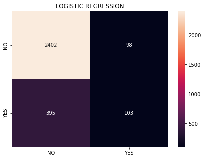

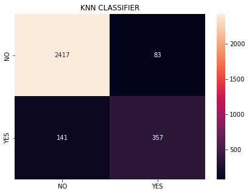

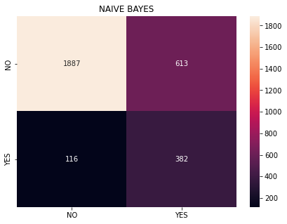

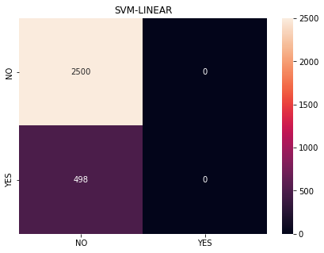

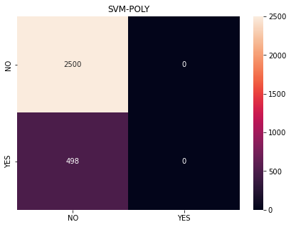

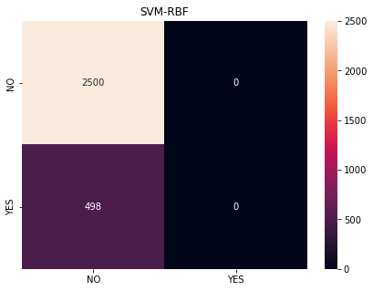

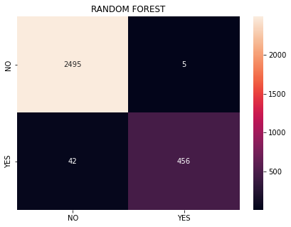

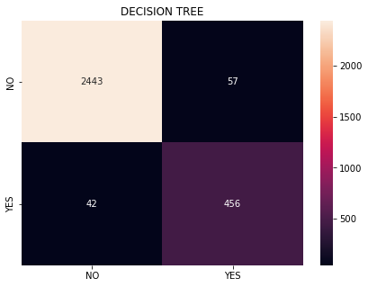

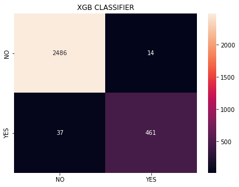

```python
CONFUSION_MATRIX(MODEL_TYPE)
```

```python
# Create a function that compares the accuracy score for the various base models and prints best performing model

def BEST_MODEL(RESULTS):
    print('MODEL WITH BEST ACCURACY:\n')
    print(RESULTS[RESULTS['ACCURACY'] == max(RESULTS['ACCURACY'])])
```

```python
BEST_MODEL(RESULTS)
```

```
MODEL WITH BEST ACCURACY:

      MODEL_NAME  ACCURACY  PRECISION    RECALL  F1-SCORE
6  RANDOM FOREST   0.98499   0.991323  0.917671  0.953076
```

```python
# Function to compare the best model with other models in performance

def CV_BESTMODEL(MODEL_TYPES,X_TRAIN_N,Y_TRAIN):
    MODEL_RESULTS = []
    MODEL_NAME = []
    scoring = 'accuracy'
    for name, model in MODEL_TYPES:
        KFOLD = model_selection.KFold(n_splits=10, random_state=7,shuffle=True)
        CV_RESULTS = model_selection.cross_val_score(model,  X_TRAIN_N,Y_TRAIN, cv = KFOLD, scoring=scoring)
        MODEL_RESULTS.append(CV_RESULTS)
        MODEL_NAME.append(name)
        msg = "%s: %f (%f)" % (name, CV_RESULTS.mean(), CV_RESULTS.std())
        print(msg)

    fig = plt.figure(figsize = (20,10))
    fig.suptitle('ALGORITHM COMPARISON')
    ax = fig.add_subplot(111)
    plt.boxplot(MODEL_RESULTS)
    ax.set_xticklabels(MODEL_NAME)
    plt.show()
```

```
LOGISTIC REGRESSION: 0.833422 (0.011972)
KNN CLASSIFIER: 0.915042 (0.012224)
NAIVE BAYES: 0.749802 (0.020352)
SVM-LINEAR: 0.833979 (0.009693)
SVM-POLY: 0.833979 (0.009693)
SVM-RBF: 0.833979 (0.009693)
RANDOM FOREST: 0.981763 (0.002825)
DECISION TREE: 0.969309 (0.004983)
XGB CLASSIFIER: 0.982653 (0.003306)
```

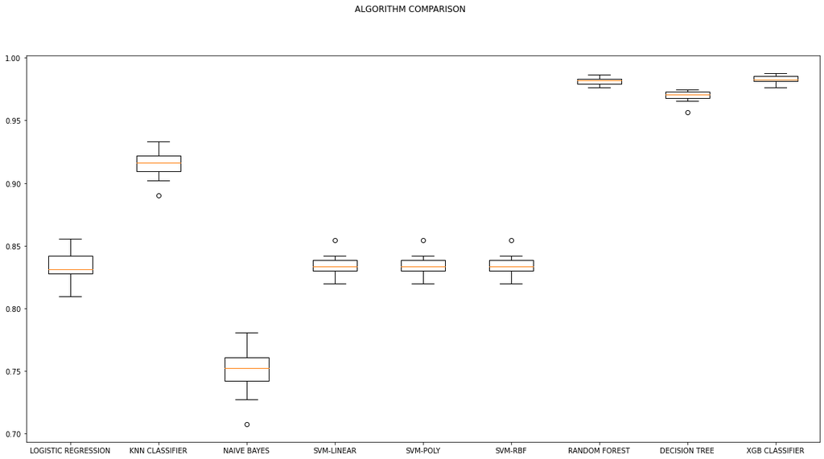

```python
CV_BESTMODEL(MODEL_TYPE,X_train_n,y_train)
```

```
LOGISTIC REGRESSION: 0.837887 (0.019199)
KNN CLASSIFIER: 0.874582 (0.021464)
NAIVE BAYES: 0.704505 (0.150735)
SVM-LINEAR: 0.833891 (0.020253)
SVM-POLY: 0.833891 (0.020253)
SVM-RBF: 0.833891 (0.020253)
RANDOM FOREST: 0.982654 (0.008145)
DECISION TREE: 0.970979 (0.005982)
XGB CLASSIFIER: 0.981988 (0.007340)
```

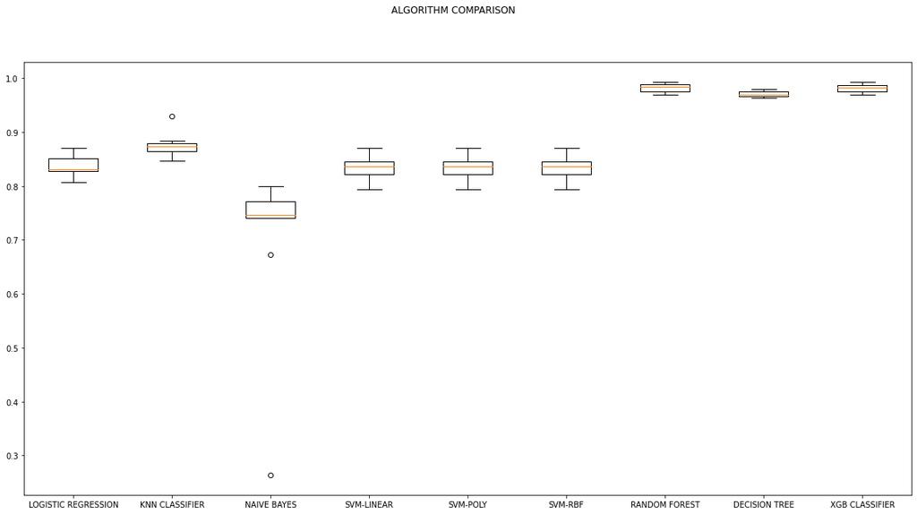

```python
#Compare the algorithms performance on test data to see which one performs better

CV_BESTMODEL(MODEL_TYPE,X_test_n,y_test)
```

```python
# Function to get the best parameters working for the model
# This function based on the input parameters given to the model, gives the best working parameters for the model

def BEST_MODEL_PARAMS(MODELS,X_TRAIN_N,Y_TRAIN):
    BEST_SCORE = []
    MODEL_NAME = []
    for name, model, params in MODELS:
        #CV = RepeatedStratifiedKFold(n_splits=10, n_repeats=3, random_state=1)
        SEARCH_BEST = RandomizedSearchCV(model, n_iter=50, scoring='accuracy',
                                         param_distributions = params, n_jobs=10, cv=3, random_state=1)
        TUNE_RESULTS = SEARCH_BEST.fit(X_TRAIN_N, Y_TRAIN)
        print(name)
        print('*******************************************************************************************')
        print('BEST SCORE: %s' % TUNE_RESULTS.best_score_)
        print('BEST PARAMETERS: %s' % TUNE_RESULTS.best_params_)
        print('\n\n')
        MODEL_NAME.append(name)
        BEST_SCORE.append(TUNE_RESULTS.best_score_)
    return MODEL_NAME, BEST_SCORE
```

```python
#Since we have Random Forest and XGB working very well compared to other models
#I have selected XGBoost as my final model to get the best parameters for the model

XGB_BEST = []

XGB_BEST.append(('XGB CLASSIFIER', XGBClassifier(eval_metric = ["auc","error"]),{'learning_rate': np.arange(0.1, 0.4, 0.2),
                                                                                   'n_estimators': np.arange(300, 501, 100),
                                                                                   'max_depth': np.arange(4, 6, 1),
                                                                                   'gamma': np.arange(0.8, 1.0, 0.1),
                                                                                   'min_child_weight': np.arange(4, 7, 2),
                                                                                   'reg_alpha': np.arange(0.5, 0.7, 0.1),
                                                                                   'reg_lambda': np.arange(0.3, 0.5, 0.1),
                                                                                   'subsample': np.arange(0.9, 1.1, 0.1),
                                                                                   'colsample_bytree': np.arange(0.7, 1.0, 0.2)}))
```

```python
BEST_MODEL_PARAMS(XGB_BEST,X_train_n,y_train)
```

```
XGB CLASSIFIER
BEST SCORE: 0.9814299140887236
BEST PARAMETERS: {'subsample': 1.0, 'reg_lambda': 0.4, 'reg_alpha': 0.6, 'n_estimators': 400, 'min_child_weight': 4, 'max_depth': 5, 'learning_rate': 0.1, 'gamma': 0.8, 'colsample_bytree': 0.7}
```

```
(['XGB CLASSIFIER'], [0.9814299140887236])
```

```python
# Repeat the same process for Random forest which is the next best performing model

RF_BEST = []

RF_BEST.append(('RANDOM FOREST', RandomForestClassifier(),{'n_estimators': np.arange(300,501,50),
                                                              'max_features': ['auto','sqrt'],
                                                              'max_depth': np.arange(4, 7, 1),
                                                              'criterion': ['gini','entropy'],
                                                              'bootstrap': [True, False]}))
```

```python
BEST_MODEL_PARAMS(RF_BEST,X_train_n,y_train)
```

```
RANDOM FOREST
BEST SCORE: 0.9537417114690853
BEST PARAMETERS: {'n_estimators': 500, 'max_features': 'auto', 'max_depth': 6, 'criterion': 'entropy', 'bootstrap': False}
```

```
(['RANDOM FOREST'], [0.9537417114690853])
```

```python
# Repeat the process for third best performing model which is decision tree

DT_BEST = []

DT_BEST.append(('DECISION TREE', DecisionTreeClassifier(),{'max_depth': [2, 3, 5, 10, 20],
                                                              'min_samples_leaf': [5, 10, 20, 50, 100],
                                                              'criterion': ["gini", "entropy"]}))
```

```python
BEST_MODEL_PARAMS(DT_BEST,X_train_n,y_train)
```

```
DECISION TREE
BEST SCORE: 0.978761394260616
BEST PARAMETERS: {'min_samples_leaf': 5, 'max_depth': 10, 'criterion': 'entropy'}
```

```
(['DECISION TREE'], [0.978761394260616])
```

```python
#Provide the best parameters from the XGBoost and print the classification report

XGB_FINAL = []

XGB_FINAL.append(("XGB CLASSIFIER", XGBClassifier(eval_metric = ["auc","error"],
                                                  subsample =  1.0,  reg_lambda =  0.4,
                                                  reg_alpha =  0.6,  n_estimators =  400,
                                                  min_child_weight =  4,  max_depth =  5,
                                                  learning_rate =  0.1,  gamma =  0.8,
                                                  colsample_bytree =  0.7)))

CLASSIFICATION_REPORT(XGB_FINAL)
```

```
CLASSIFICATION REPORT FOR  XGB CLASSIFIER
              precision    recall  f1-score   support

           0       0.98      1.00      0.99      2500
           1       0.97      0.92      0.95       498

    accuracy                           0.98      2998
   macro avg       0.98      0.96      0.97      2998
weighted avg       0.98      0.98      0.98      2998
```

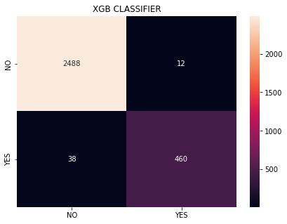

```python
CONFUSION_MATRIX(XGB_FINAL)
```

# pacE: Execute Stage

- Interpret model performance and results
- Share actionable steps with stakeholders

✏

## Recall evaluation metrics

- **AUC** is the area under the ROC curve; it's also considered the probability that the model ranks a random positive example more highly than a random negative example.
- **Precision** measures the proportion of data points predicted as True that are actually True, in other words, the proportion of positive predictions that are true positives.
- **Recall** measures the proportion of data points that are predicted as True, out of all the data points that are actually True. In other words, it measures the proportion of positives that are correctly classified.
- **Accuracy** measures the proportion of data points that are correctly classified.
- **F1-score** is an aggregation of precision and recall.

💭

### Reflect on these questions as you complete the executing stage.

- What key insights emerged from your model(s)?
- What business recommendations do you propose based on the models built?
- What potential recommendations would you make to your manager/company?
- Do you think your model could be improved? Why or why not? How?
- Given what you know about the data and the models you were using, what other questions could you address for the team?
- What resources do you find yourself using as you complete this stage? (Make sure to include the links.)
- Do you have any ethical considerations in this stage?

```
 Out of all the models I have used for predicting the outcomes, Decision Tree, Random Forest and XGBoost has given high accuracy scores compared to Logistic Regression, KNN and Support Vector Machine. This might be due to the type of data presented for us which involves making a decision based on the parameters. In these scenarios any variant of decision tree model seems to outperform the other models since we are making a decision on the data set. Since we got accuracy scores of more than 95% in the three models we have to see the other scores like precision, recall and f1_score. Based on all these factors we have selected XGBoost as the best and final model that accurately predicts the data.
```

## Step 4. Results and Evaluation

- Interpret model
- Evaluate model performance using metrics
- Prepare results, visualizations, and actionable steps to share with stakeholders

### Summary of model results

Refer to the cell blocks above in the step 3 where I have made comparison of scores from all the 9 models. I have made the visual comparison between all the models to get a clear idea on how a model is predicting. Also I have printed confusion matrix and classification report for all the 9 models where the stake holder sees how the models are performing.

### Conclusion, Recommendations, Next Steps

```
- As I mentioned earlier, we have observed that there is bias in the model where it is more inclined to class 0 than to class 1. This can be clearly seen in the confusion matrix where more data is present in class 0 than to class 1. Since I have used data as is to give straight forward results of what story the data given is sharing to ensure the stake holders also the importance of providing good amount of data without bias. As next step, I share all my insights with the stake holders, explain clearly all the steps involded. How modular my overall program is that will use functions to build a model and fitting the data and predicting the results which makes it easier for other team members just to give only the model as parameter and get the best parameters for that model and simplified the process of cross validation, printing classification report and confusion matrix.

Happy Learning!
```

**Congratulations!** You've completed this lab. However, you may not notice a green check mark next to this item on Coursera's platform. Please continue your progress regardless of the check mark. Just click on the "save" icon at the top of this notebook to ensure your work has been logged.